# Biostat M280 Homework 4

Due Mar 16 @ 11:59PM

Our Apache Yarn cluster hosts the [flights](http://stat-computing.org/dataexpo/2009/the-data.html) data representing 123 million flights over 22 years. Read the [lecture notes](http://hua-zhou.github.io/teaching/biostatm280-2018winter/slides/12-sparklyr/sparklyr-flights.html) on how to access the Yarn cluster. Connect to the database using `sparklyr` and answer following questions. You can base your answers on a specific year or the whole data set.

```r
Sys.setenv(SPARK_HOME = "/usr/lib/spark")
config <- spark_config()
sc <- spark_connect(master = "local", config = config)


airlines_tbl <- tbl(sc, 'airlines')
airlines_tbl %>% print(width = Inf)
```

```
## # Source:   table<airlines> [?? x 2]
## # Database: spark_connection
##    code  description
##    <chr> <chr>
##  1 Code  Description
##  2 02Q   Titan Airways
##  3 04Q   Tradewind Aviation
##  4 05Q   Comlux Aviation, AG
##  5 06Q   Master Top Linhas Aereas Ltd.
##  6 07Q   Flair Airlines Ltd.
##  7 09Q   Swift Air, LLC d/b/a Eastern Air Lines d/b/a Eastern
##  8 0BQ   DCA
##  9 0CQ   ACM AIR CHARTER GmbH
## 10 0FQ   Maine Aviation Aircraft Charter, LLC
## # ... with more rows
```

```r
airports_tbl <- tbl(sc, 'airports')
airports_tbl %>% print(width = Inf)
```

```
## # Source:   table<airports> [?? x 12]
## # Database: spark_connection
##    id    name                                        city
##    <chr> <chr>                                       <chr>
##  1 1     Goroka Airport                              Goroka
##  2 2     Madang Airport                              Madang
##  3 3     Mount Hagen Kagamuga Airport                Mount Hagen
##  4 4     Nadzab Airport                              Nadzab
##  5 5     Port Moresby Jacksons International Airport Port Moresby
##  6 6     Wewak International Airport                 Wewak
##  7 7     Narsarsuaq Airport                          Narssarssuaq
##  8 8     Godthaab / Nuuk Airport                     Godthaab
##  9 9     Kangerlussuaq Airport                       Sondrestrom
## 10 10    Thule Air Base                              Thule
##    country          faa   icao  lat                lon
```

[output cut: 24 more lines]

```r
flights_tbl <- tbl(sc, 'flights')
flights_tbl %>% print(width = Inf)
```

```
## # Source:   table<flights> [?? x 29]
## # Database: spark_connection
##     year month dayofmonth dayofweek deptime crsdeptime arrtime crsarrtime
##    <int> <int>      <int>     <int>   <int>      <int>   <int>      <int>
##  1    NA    NA         NA        NA      NA         NA      NA         NA
##  2  1987    10         14         3     741        730     912        849
##  3  1987    10         15         4     729        730     903        849
##  4  1987    10         17         6     741        730     918        849
##  5  1987    10         18         7     729        730     847        849
##  6  1987    10         19         1     749        730     922        849
##  7  1987    10         21         3     728        730     848        849
##  8  1987    10         22         4     728        730     852        849
##  9  1987    10         23         5     731        730     902        849
## 10  1987    10         24         6     744        730     908        849
##    uniquecarrier flightnum tailnum actualelapsedtime crselapsedtime
```

[output cut: 48 more lines]

1. Map the top 10 busiest airports. Size of dots should reflect the number of flights through that destination.  
   Hint: You may find this tutorial on [Making Maps in R](http://eriqande.github.io/rep-res-web/lectures/making-maps-with-R.html) helpful.

   I mapped the top 10 busiest airports.

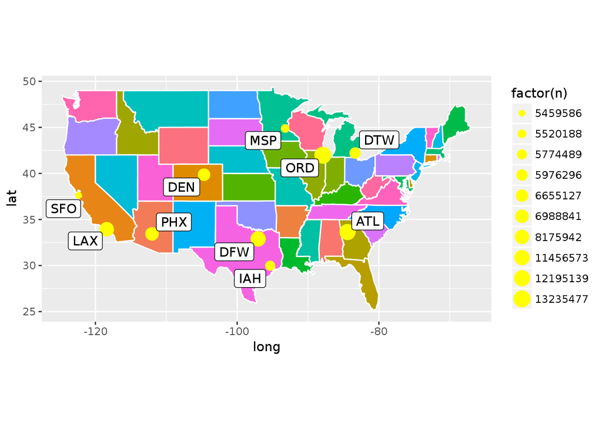

   ```r
   d <- flights_tbl %>%
     group_by(dest) %>%
     summarise(ndest = n()) %>%
     arrange(desc(ndest)) %>%
     head(10) %>%
     collect()

   o <- flights_tbl %>%
     group_by(origin) %>%
     summarise(norigin = n()) %>%
     arrange(desc(norigin)) %>%
     head(10) %>%
     collect()

   do <- left_join(d, o, by = c("dest" = "origin")) %>%
     transmute(port = dest, n = ndest + norigin) %>%
     collect()

   states <- map_data("state")

   airports_tbl %>%
     left_join(do, by = c("faa" = "port"), copy = TRUE) %>%
     mutate(faa, lat = as.numeric(lat), lon = as.numeric(lon)) %>%
     filter(faa %in% do$port) %>%
     collect() %>%
     ggplot() +
     geom_polygon(data = states, aes(x = long,
       y = lat, fill = region, group = group), color = "white") +
     geom_point(mapping = aes(x = lon, y = lat, size = factor(n)),
                color = "yellow") +
     geom_label_repel(aes(x = lon, y = lat, label = faa)) +
     coord_fixed(1.3) +
     guides(fill=FALSE)
   ```

2. Map the top 10 busiest direct routes. Size of lines should reflect the number of flights through that route.

   I mapped the top 10 busiest direct routes.

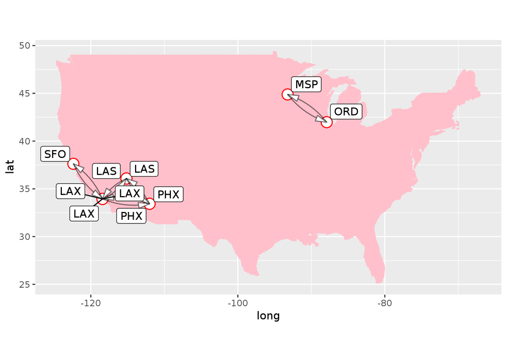

   ```r
   usa <- map_data("usa")
   busyr <- flights_tbl %>%
     group_by(origin, dest) %>%
     summarise(num = n()) %>%
     arrange(desc(num)) %>%
     head(10) %>%
     collect()

   #mutate(faa, lat = as.numeric(lat), lon = as.numeric(lon)) %>%

   lorigin <- airports_tbl %>%
     select(faa, lon, lat) %>%
     filter(faa %in% busyr$origin) %>%
     transmute(faa, olat = as.numeric(lat), olon = as.numeric(lon)) %>%
     collect()

   ldest <- airports_tbl %>%
     select(faa, lon, lat) %>%
     filter(faa %in% busyr$dest) %>%
     transmute(faa, dlat = as.numeric(lat), dlon = as.numeric(lon)) %>%
     collect()

    busyr %>%
      left_join(lorigin, by = c("origin" = "faa")) %>%
      left_join(ldest, by = c("dest" = "faa")) %>%
      mutate(line_scale = (num/max(num))^10) %>%
      collect() %>%
      ggplot() +
      geom_polygon(data = usa, aes(x=long, y = lat, group = group),
                  fill = "pink", color = "pink") +
      geom_point(aes(x = olon, y = olat), color = "red", size = 5) +
      geom_point(aes(x = dlon, y = dlat), color = "white", size = 4) +
      geom_curve(aes(x = olon, y = olat, xend = dlon, yend = dlat,
                     fill = line_scale),
                arrow = arrow(angle = 15, length = unit(0.4,"cm"),
                            type="closed"),
                alpha = 0.5, curvature = 0.15) +
      geom_label_repel(aes(x = olon, y = olat, label = origin)) +
      coord_fixed(1.3)
   ```

3. LAX:

   (a). Reproduce above plot. Visualize and explain some prominent features you observe. For example, what happened at points 1-5?

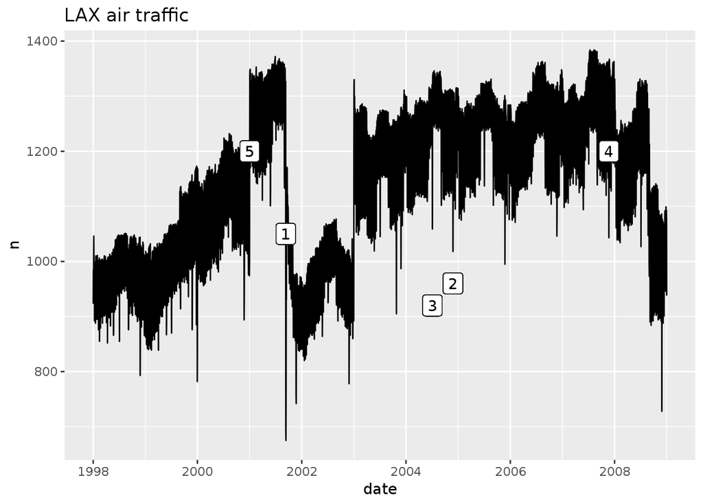

   ```r
   laxairtr <- flights_tbl %>%
     filter(year >= 1998 & year <= 2008) %>%
     #filter(date %in% c(ymd(19980101):ymd(20081231))) %>%
     filter(origin == "LAX" | dest == "LAX" &
            !is.na(year) & !is.na(month) & !is.na(dayofmonth) &
              !is.na(dayofweek) & !is.na(arrdelay) & !is.na(depdelay) &
              !is.na(distance) & !is.na(uniquecarrier)) %>%
     select(origin, dest, year, month, dayofmonth,
            dayofweek, arrdelay, depdelay, distance, uniquecarrier) %>%
     collect()

   saveRDS(laxairtr,
           file = "~/biostat-m280-2018-winter/hw4/laxairtr.rds")
   laxairtr <- readRDS("~/biostat-m280-2018-winter/hw4/laxairtr.rds")

   ########q3a data for plot
     q3a <- laxairtr %>%
     select(origin, dest, year, month, dayofmonth) %>%
     mutate(date = make_date(year, month, dayofmonth)) %>%
     collect()

     p3a <- q3a %>%
       group_by(date) %>%
       count() %>%
       ggplot() +
       geom_line(aes(x = date, y = n)) +
       ggtitle("LAX air traffic") +
       xlab("date") + ylab("n") +
       geom_label(aes(x = ymd(20010911), y = 1050, label = "1")) +
       geom_label(aes(x = ymd(20041125), y = 960, label = "2")) +
       geom_label(aes(x = ymd(20040704), y = 920, label = "3")) +
       geom_label(aes(x = ymd(20071122), y = 1200, label = "4")) +
       geom_label(aes(x = ymd(20010101), y = 1200, label = "5"))
     p3a
   ```

   ```r
   ################zoom in 1
     p3a1 <- p3a +
       coord_fixed(xlim = (c(ymd(20010910), ymd(20010920))), ratio = 0.01) +
       ggtitle("Point 1. 20110911")
     p3a1
   ```

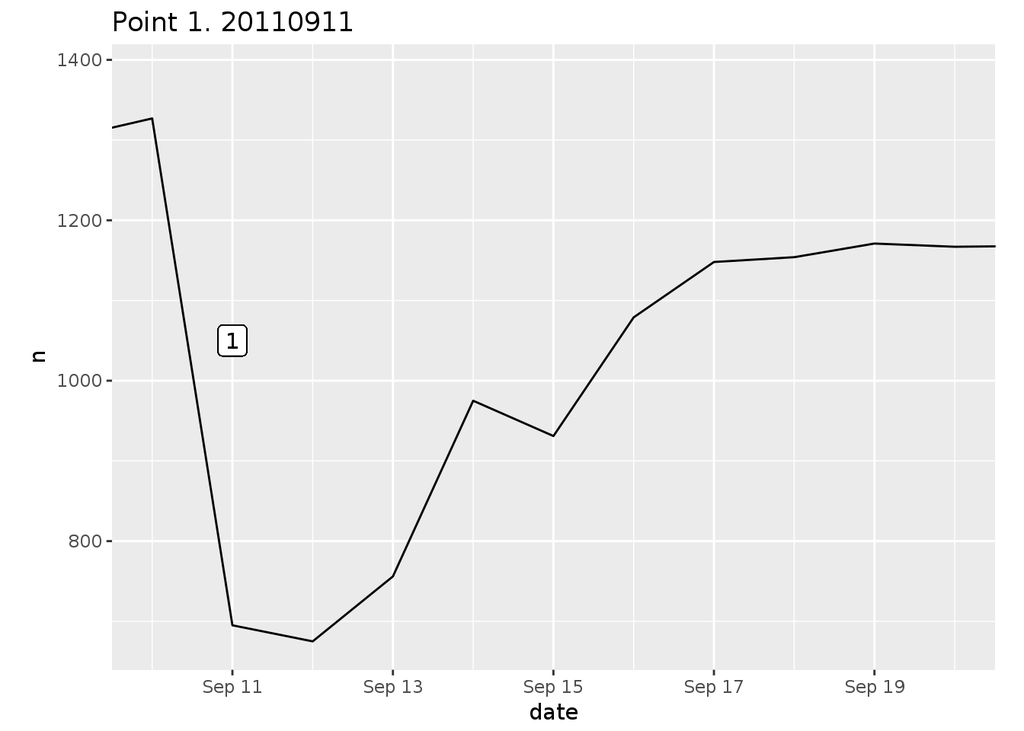

   ```r
   ################zoom in 2
     p3a2 <- p3a +
       coord_fixed(xlim = (c(ymd(20041122), ymd(20041130))), ratio = 0.01) +
       ggtitle("Point 2. 20041125")
     p3a2
   ```

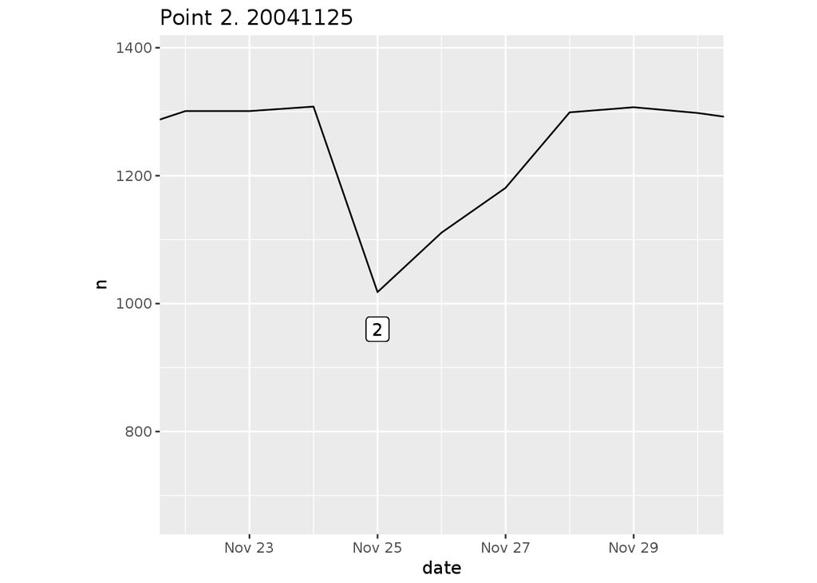

   There is a sudden drop at Point 3 on July 4, 2004, which is the Independence Day. People celebrated the special day instead of traveling to the destination.

   ```r
   ################zoom in 3
     p3a3 <- p3a +
       coord_fixed(xlim = (c(ymd(20040701), ymd(20040708))), ratio = 0.01) +
       ggtitle("Point 3. 20040704")
     p3a3
   ```

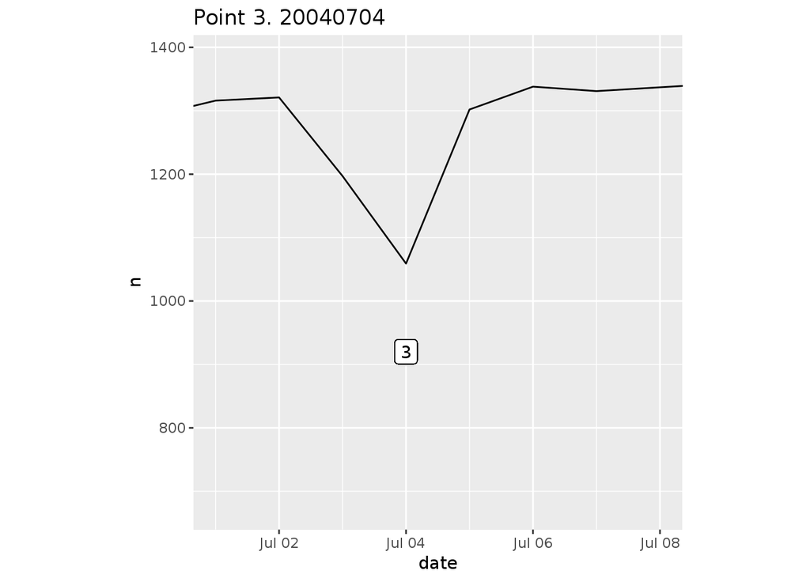

   ```r
   ################zoom in 4
     p3a4 <- p3a +
       coord_fixed(xlim = (c(ymd(20071119), ymd(20071128))), ratio = 0.01) +
       ggtitle("Point 4. 20071122")
     p3a4
   ```

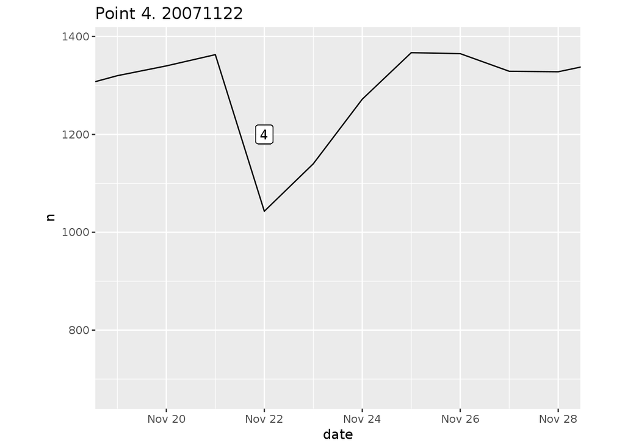

   ```r
   ################zoom in 5
     p3a5 <- p3a +
       coord_fixed(xlim = (c(ymd(20001115), ymd(20010105))), ratio = 0.05) +
       ggtitle("Point 5. 20010101")
     p3a5
   ```

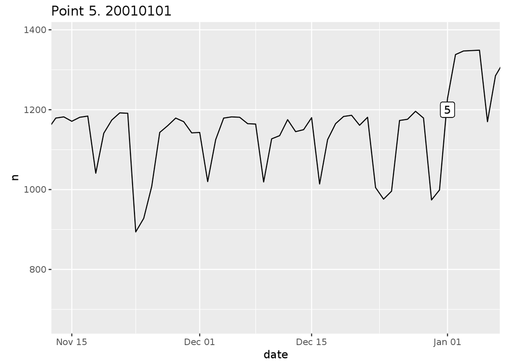

   (b). Visualize and explain seasonal effects.

   Season definition: Spring runs from March to May; Summer runs from June to August; Fall runs from September to November; Winter runs from December to February.

   From 1998 to 2008, the number of flights in Summer was always the highest among all four seasons, except in 1999, when the number of flights in Fall was the highest. In general, the number of flights in Winter is the lowest. Summer is the best travel season for students since they have a long summer break. For the Summer in 1999, one of highest temperatures ever recorded occurred in July (https://www.weather.gov/gsp/july_1999) that that might be one of the reasons that the number of flights in Summer was not the highest among all four seasons in 1999. Due to the cold weather, people do not travel that much during the winter. For students, the winter break is usually much shorter than the summer break so fewer students choose to travel in Winter. For Spring, even though the weather is pleasant, most people are busy with working or school so they do not get the chance to travel that much during spring. Therefore, the number of the flights in Spring is usually lower that that in Summer.

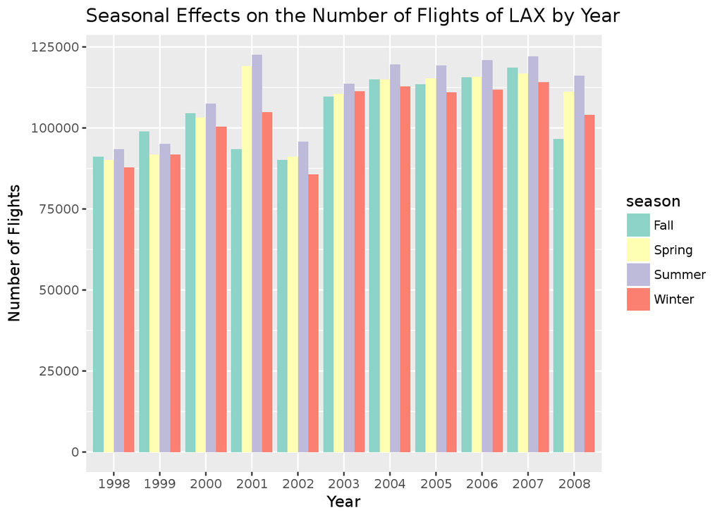

   ```r
   laxairtr %>%
     select(origin, dest, year, month, dayofmonth) %>%
           mutate(season =
              if_else(month %in% 9:11, "Fall",
                      if_else(month %in% c(12, 1, 2), "Winter",
                              if_else(month %in% 3:5, "Spring",
                                      if_else(month %in% 6:8, "Summer", "")
                                      )
                              )
                      )
            ) %>%
     group_by(year, season) %>%
     summarise(n = n()) %>%
     collect() %>%
     ggplot() +
     geom_col(aes(x = as.factor(year), y = n, fill = season),
          position = "dodge") +
     labs(x = "Year", y = "Number of Flights") +
     ggtitle("Seasonal Effects on the Number of Flights of LAX by Year") +
     scale_fill_brewer(palette ="Set3")
   ```

   (c). Visualize and explain weekly effects.

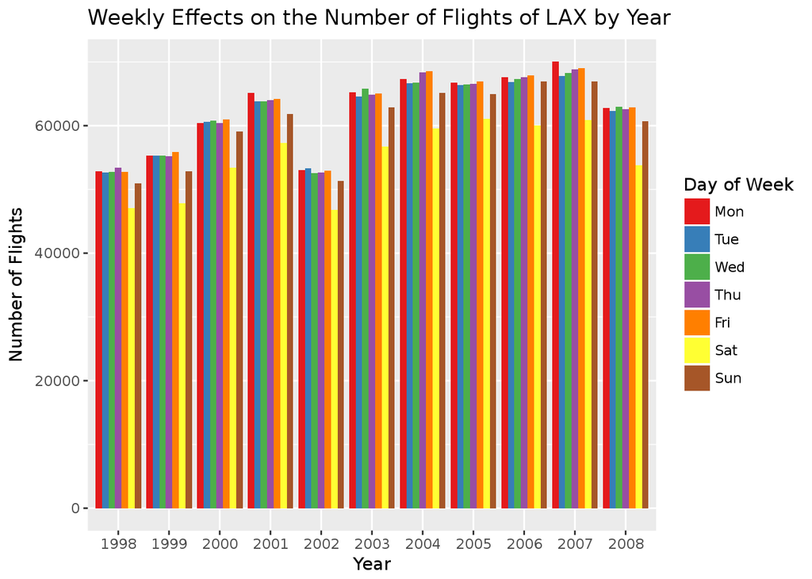

   ```r
   laxairtr %>%
     select(origin, dest, year, dayofweek) %>%
     group_by(year, dayofweek) %>%
     summarise(n = n()) %>%
     collect() %>%
     ggplot() +
     geom_col(aes(x = as.factor(year), y = n, fill = as.factor(dayofweek)),
          position = "dodge") +
     labs(x = "Year", y = "Number of Flights") +
     ggtitle("Weekly Effects on the Number of Flights of LAX by Year") +
     scale_fill_brewer(name = "Day of Week",
                 labels = c("Mon", "Tue", "Wed", "Thu", "Fri", "Sat", "Sun"),
                 palette = "Set1")
   ```

   (d). Map top 10 destinations from LAX. Size of dots should reflect the number of flights from LAX to that destination.

   I mapped top 10 destinations from LAX.

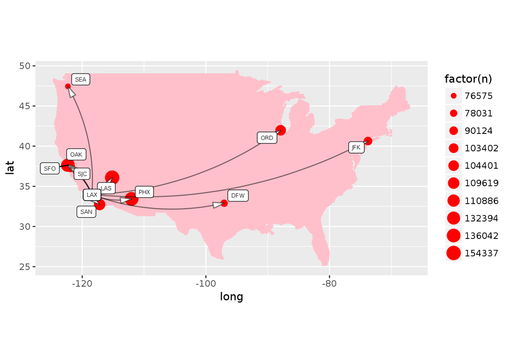

   ```r
   usa <- map_data("usa")

   topd <- laxairtr %>%
     filter(origin == "LAX" & !is.na(dest)) %>%
     select(origin, dest) %>%
     group_by(origin, dest) %>%
     summarise(n = n()) %>%
     arrange(desc(n)) %>%
     head(10) %>%
     collect()

   ld <- airports_tbl %>%
     select(faa, lat, lon) %>%
     left_join(topd, by = c("faa" = "dest"), copy = TRUE) %>%
     filter(faa %in% topd$dest) %>%
     transmute(n, dest = faa,
               ddlat = as.numeric(lat), ddlon = as.numeric(lon)) %>%
     collect()

   lo <- airports_tbl %>%
     select(faa, lat, lon) %>%
     left_join(topd, by = c("faa" = "origin"), copy = TRUE) %>%
     filter(faa %in% topd$origin) %>%
     transmute(dest, origin = faa,
               oolat = as.numeric(lat), oolon = as.numeric(lon)) %>%
     collect()

   ldo <- ld %>%
     left_join(lo, by = c("dest" = "dest")) %>%
     select(origin, dest, n, oolat, oolon, ddlat, ddlon) %>%
     collect()

   ldo %>%
     ggplot() +
     geom_polygon(data = usa, aes(x = long, y = lat, group = group),
                  fill = "pink", color = "pink") +
     geom_point(aes(x = oolon, y = oolat), color = "purple", size = 5) +
     geom_point(aes(x = ddlon, y = ddlat, size = factor(n)), color = "red") +
     geom_curve(aes(x = oolon, y = oolat, xend = ddlon, yend = ddlat),
                arrow = arrow(angle = 15, length = unit(0.4,"cm"),
                            type ="closed"),
                alpha = 0.5, curvature = 0.15) +
     geom_label_repel(aes(x = ddlon, y = ddlat, label = dest), size = 2) +
     geom_label(aes(x = -118.408, y = 33.9425, label = "LAX"), size = 2) +
     coord_fixed(1.3)
   ```

4. Build a predictive model for the arrival delay (`arrdelay`) of flights flying from LAX. Use the same filtering criteria as in the [lecture notes](http://hua-zhou.github.io/teaching/biostatm280-2018winter/slides/12-sparklyr/sparklyr-flights.html) to construct training and validation sets. You are allowed to use a maximum of 5 predictors. The prediction performance of your model on the validation data set will be an important factor for grading this question.

   ```r
   # want to fit a linear regression of arrdelay on distance, departure delay, and carriers using data from 2003-2007
   model_data <- flights_tbl %>%
   filter(!is.na(arrdelay) & !is.na(depdelay) & !is.na(distance)) %>%
   filter(depdelay > 15 & depdelay < 240) %>%
   filter(arrdelay > -60 & arrdelay < 360) %>%
   filter(year >= 2003 & year <= 2007) %>%
   left_join(airlines_tbl, by = c("uniquecarrier" = "code"), copy = TRUE) %>%
   select(year, month, arrdelay, depdelay,
          distance, uniquecarrier, description)

   # Summarize data by carrier
   model_data %>%
   group_by(uniquecarrier) %>%
   summarize(description = min(description), arrdelay = mean(arrdelay),
             distance = mean(distance), depdelay = mean(depdelay)) %>%
   select(description, arrdelay, distance, depdelay) %>%
   arrange(arrdelay)
   ```

   ```
   ## # Source:     lazy query [?? x 4]
   ## # Database:   spark_connection
   ## # Ordered by: arrdelay
   ##    description                                  arrdelay distance depdelay
   ##    <chr>                                           <dbl>    <dbl>    <dbl>
   ##  1 Aloha Airlines Inc.                              38.1     725.     41.6
   ##  2 Frontier Airlines Inc.                           40.8     914.     41.1
   ##  3 Southwest Airlines Co.                           40.9     609.     44.9
   ##  4 America West Airlines Inc. (Merged with US …     44.7    1070.     48.4
   ##  5 Hawaiian Airlines Inc.                           44.9    1416.     47.4
   ##  6 Alaska Airlines Inc.                             48.6     874.     50.4
   ##  7 US Airways Inc.                                  48.9     816.     49.0
   ##  8 Northwest Airlines Inc.                          50.7     779.     48.5
   ##  9 SkyWest Airlines Inc.                            52.4     397.     52.3
   ## 10 Delta Air Lines Inc.                             52.6     868.     50.8
   ## # ... with more rows
   ```

   ```r
   #################Train a linear model
   #Partition the data into training and validation sets
   model_partition <- model_data %>%
     sdf_partition(train = 0.8, valid = 0.2, seed = 5555)

   #fit a linear model
    ml1 <- model_partition$train %>%
      ml_linear_regression(arrdelay ~ distance + depdelay + uniquecarrier)

   #Summarize the linear model
    summary(ml1)
   ```

   ```
   ## Call: ml_linear_regression.tbl_spark(., arrdelay ~ distance + depdelay + uniquecarrier)
   ##
   ## Deviance Residuals (approximate):
   ##     Min      1Q  Median      3Q     Max
   ## -79.420  -9.792  -2.787   5.494 305.422
   ##
   ## Coefficients:
   ##      (Intercept)         distance         depdelay uniquecarrier_WN
   ##     -1.744310611     -0.003265998      1.014662325     -0.876124221
   ## uniquecarrier_AA uniquecarrier_MQ uniquecarrier_UA uniquecarrier_DL
   ##      5.314241548      4.870711724      3.670680336      5.676217564
   ## uniquecarrier_US uniquecarrier_OO uniquecarrier_EV uniquecarrier_NW
   ##      3.603629208      2.367797953      1.052889012      5.783125644
   ## uniquecarrier_XE uniquecarrier_CO uniquecarrier_OH uniquecarrier_FL
   ##      5.584317607      5.513917180      2.152535205      4.454803437
   ## uniquecarrier_AS uniquecarrier_DH uniquecarrier_YV uniquecarrier_B6
   ##      2.067187427      0.754864480     -0.123395029      4.945583357
   ## uniquecarrier_HP uniquecarrier_9E uniquecarrier_F9 uniquecarrier_TZ
   ##      0.894187818      2.987736373      3.885617746      7.986040267
   ## uniquecarrier_HA
   ##      3.132802810
   ##
   ## R-Squared: 0.8449
   ## Root Mean Squared Error: 17.74
   ```

   ```r
   #Compare actual arrdelays to predicted arrdelays for an out of time sample.
   data_2008 <- flights_tbl %>%
     filter(!is.na(arrdelay) & !is.na(depdelay) & !is.na(distance)) %>%
     filter(depdelay > 15 & depdelay < 240) %>%
     filter(arrdelay > -60 & arrdelay < 360) %>%
     filter(year == 2008) %>%
     left_join(airlines_tbl, by = c("uniquecarrier" = "code")) %>%
     select(year, month, arrdelay, depdelay, distance, uniquecarrier,
            description, origin, dest)
   data_2008
   ```

   ```
   ## # Source:   lazy query [?? x 9]
   ## # Database: spark_connection
   ##     year month arrdelay depdelay distance uniquecarrier description origin
   ##    <int> <int>    <int>    <int>    <int> <chr>         <chr>       <chr>
   ##  1  2008     1        2       19      810 WN            Southwest … IAD
   ##  2  2008     1       34       34      515 WN            Southwest … IND
   ##  3  2008     1       11       25      688 WN            Southwest … IND
   ##  4  2008     1       57       67     1591 WN            Southwest … IND
   ##  5  2008     1       80       94      828 WN            Southwest … IND
   ##  6  2008     1       15       27     1489 WN            Southwest … IND
   ##  7  2008     1       16       28      838 WN            Southwest … IND
   ##  8  2008     1       37       51      220 WN            Southwest … ISP
   ##  9  2008     1       19       32      220 WN            Southwest … ISP
   ## 10  2008     1        6       20      220 WN            Southwest … ISP
   ## # ... with more rows, and 1 more variable: dest <chr>
   ```

   ```r
   # Summarize data by carrier
   carrier <- sdf_predict(ml1, data_2008) %>%
     group_by(description) %>%
     summarize(arrdelay = mean(arrdelay), prediction = mean(prediction),
               freq = n()) %>%
     filter(freq > 10000) %>%
     collect()
   carrier
   ```

   ```
   ## # A tibble: 18 x 4
   ##    description                  arrdelay prediction    freq
   ##    <chr>                           <dbl>      <dbl>   <dbl>
   ##  1 Continental Air Lines Inc.       54.5       57.5  61386.
   ##  2 Delta Air Lines Inc.             53.5       53.7  69066.
   ##  3 ExpressJet Airlines Inc. (1)     61.7       64.2  70037.
   ##  4 Mesa Airlines Inc.               65.1       63.1  48208.
   ##  5 PSA Airlines Inc.                61.0       58.3  36958.
   ##  6 Endeavor Air Inc.                58.5       59.6  35039.
   ##  7 Southwest Airlines Co.           44.4       44.6 224655.
   ##  8 American Airlines Inc.           57.5       57.7 131798.
   ##  9 JetBlue Airways                  64.3       63.9  38257.
   ## 10 US Airways Inc.                  50.9       52.8  59418.
   ## 11 ExpressJet Airlines Inc.         58.4       57.6  56247.
   ## 12 Frontier Airlines Inc.           41.7       41.1  14674.
   ## 13 Alaska Airlines Inc.             49.2       48.7  23806.
   ## 14 SkyWest Airlines Inc.            60.4       59.3  85859.
   ## 15 United Air Lines Inc.            59.7       61.1  97408.
   ## 16 Envoy Air                        55.7       55.6  97086.
   ## 17 AirTran Airways Corporation      57.5       56.8  44867.
   ## 18 Northwest Airlines Inc.          52.9       52.1  49220.
   ```

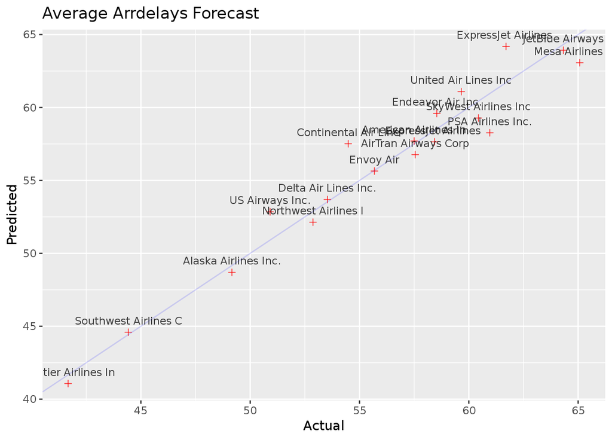

   ```r
   # Plot actual arrdelays and predicted arrdelays by airline carrier
   ggplot(carrier, aes(arrdelay, prediction)) +
     geom_point(alpha = 0.75, color = 'red', shape = 3) +
     geom_abline(intercept = 0, slope = 1, alpha = 0.15, color = 'blue') +
     geom_text(aes(label = substr(description, 1, 20)), size = 3,
               alpha = 0.75, vjust = -1) +
     labs(title='Average Arrdelays Forecast', x = 'Actual', y = 'Predicted')
   ```

5. Visualize and explain any other information you want to explore.

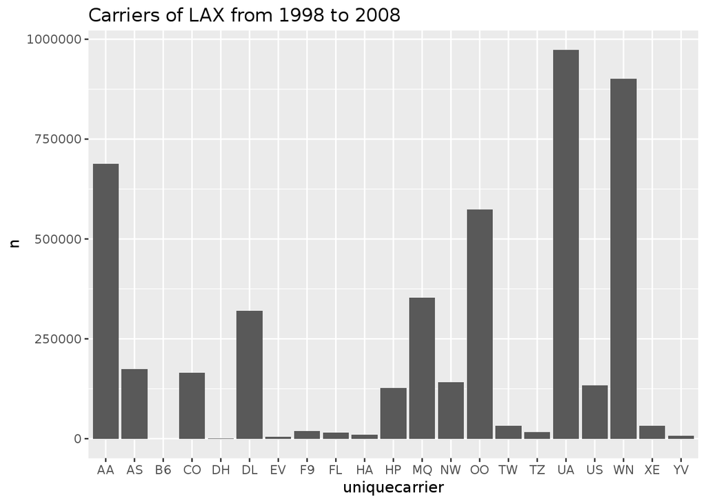

   ```r
   laxairtr %>%
     select(dest, uniquecarrier) %>%
     group_by(uniquecarrier) %>%
     count() %>%
     collect() %>%
     ggplot() +
     geom_col(aes(x = uniquecarrier, y = n)) +
     ggtitle("Carriers of LAX from 1998 to 2008")
   ```

```r
spark_disconnect_all()
```

```
## [1] 1
```